# Overview

Nice to meet you. This machine learning project has been one of my great passion projects for quite some time and I am incredibly happy to be able to finally implement my ideas. This field is incredibly vast and I have only just scraped the surface, so I am excited to learn more and build more projects! I intend for this to be a "living" project that I would incrementally improve as my knowledge and understanding of data science and machine learning improves over time.

## Options Pricing using Machine Learning Models

This project aims to predict option prices using various machine learning models and I intend to implement and experiment with different algorithms. At the moment, it employs the K-Nearest Neighbors (KNN) algorithm for its prediction task. However, I am open to using different models as I gain more experience and knowledge. Furthermore, the project also uses the Black-Scholes formula to calculate theoretical prices which is used as a benchmark to compare the predictive ability of the machine learning model. My goal is to create a model that has predictive abilities comparable to the Black-Scholes formula.

## Data Source and Features

We are using options chain data obtained from OptionsDX for all of 2022.

*Features names that are prefixed with "C_" indicate it is a call and "P_" indicates it is an option*

STRIKE_DISTANCE: Distance from the strike price to the underlying price

STRIKE: Strike price

DTE: Days until the expiration of the contract

ASK: Ask price

BID: Bid price

IV: Implied volatility

DELTA: How much the option price changes for every $1 change in the options price

GAMMA: How much the delta changes for every $1 change in the options price

VEGA: How much the option price changes for every 1% in the implied volatility

THETA: How much the option price decreases in value every day

IV: Implied volatility of the options

LAST: Last traded price, which we are modeling to predict

## Data Preprocessing

After chunking the data from the csv file and appending it to the dataframes, we then start cleaning the data by dropping any missing values. We then split the data into features (X) and the target variable (y) for the both calls and puts. The data is split to be 80% training and 20% testing. Before applying the machine learning models, the feature variables are standardized and normalized using StandardScaler.

## Data Analysis

Next, we graph the data and find the descriptive statistics to provide an understanding of the underlying features that are being used to train the model. We are visualizing the data using matplotlib and pyplot. We have plotted a histogram for each of the features in the calls and puts.

## Data Visualization

We use Matplotlib to visualize the data as well as compare the outputs of the model between the actual values. This provides an intuitive understanding of the performance of our model. We are also visualizing the errors of the predictions in order to better understand the model's performance. Finally, we are using the Black-Scholes model as a benchmark to compare the predictive ability of the model.

## Future Improvements

There is a lot of room for growth and improvement in this project. As I mentioned earlier, I intend for this to be a living project that is incrementally improved as my understanding of the concepts of machine learning grows. Potential future improvements could include using more sophisticated models, adding more features, working with a larger dataset, and adding time series forecasting models.

```python
# Import the necessary libaries
import pandas as pd
import numpy as np
# import datetime
# import yfinance as yf
import scipy.stats as stats
from sklearn.model_selection import train_test_split #, GridSearchCV
from sklearn.preprocessing import StandardScaler
from sklearn.metrics import mean_squared_error, mean_absolute_error, r2_score
from sklearn.neighbors import KNeighborsRegressor
# from sklearn.linear_model import LinearRegression
# from sklearn.tree import DecisionTreeRegressor
import matplotlib.pyplot as plt
import seaborn as sns
# import logging
```

[figure not shown]

```python
# Formula for equation as shown above
def black_scholes(row, option='call'):
    S = row['UNDERLYING_LAST'] # Underlying asset price
    K = row['STRIKE'] # Strike price
    T = row['DTE'] / 365.0 # Time to maturity in years
    r = 0.01 # Risk-free rate (We are going to assume it is 1%)
    σ = row['C_IV'] if option == 'call' else row['P_IV'] # Implied volatility

    d1 = (np.log(S / K) + ((r + ((σ ** 2) / 2)) * T)) / (σ * np.sqrt(T))
    d2 = d1 - (σ * np.sqrt(T))

    if option == 'call':
        return stats.norm.cdf(d1, 0.0, 1.0) * S - stats.norm.cdf(d2, 0.0, 1.0) * K * np.exp(-r * T)
    elif option == 'put':
        return stats.norm.cdf(-d2, 0.0, 1.0) * K * np.exp(-r * T) - stats.norm.cdf(-d1, 0.0, 1.0) * S

# Since the csv files are relatively large (~10 GB each), we are chunking the data and processing the records chunk by chunk
# Then we are concatenating it to the pandas dataframe
def load_and_process(filename, chunksize=10**6):
    # We are predicing C_LAST and P_LAST
    relevant_call_features = ['C_LAST', 'UNDERLYING_LAST', 'DTE', 'STRIKE', 'STRIKE_DISTANCE', 'C_BID', 'C_ASK', 'C_IV', 'C_DELTA', 'C_GAMMA', 'C_VEGA', 'C_THETA']
    relevant_put_features = ['P_LAST', 'UNDERLYING_LAST', 'DTE', 'STRIKE', 'STRIKE_DISTANCE', 'P_BID', 'P_ASK', 'P_IV', 'P_DELTA', 'P_GAMMA', 'P_VEGA', 'P_THETA']

    columns = pd.read_csv(filename, nrows=0).columns.tolist()
    print("Columns:", columns)

    # Initial empty dataframes
    df_calls = pd.DataFrame()
    df_puts = pd.DataFrame()

    for chunk in pd.read_csv(filename, skiprows=1, header=None, names=columns, chunksize=chunksize):
        chunk_calls = chunk[relevant_call_features]
        chunk_puts = chunk[relevant_put_features]

        # We know if it is a call or put if the bid value is not 0
        is_call = chunk_calls['C_BID'] != 0.0
        is_put = chunk_puts['P_BID'] != 0.0

        # Appending the chunked data to the data frames
        df_calls = pd.concat([df_calls, chunk_calls[is_call]], ignore_index=True)
        df_puts = pd.concat([df_puts, chunk_puts[is_put]], ignore_index=True)

    # Dropping the empty rows
    df_calls = df_calls.dropna(subset=['C_LAST'])
    df_puts = df_puts.dropna(subset=['P_LAST'])

    # Drop Nan values as well
    df_calls = df_calls.dropna()
    df_puts = df_puts.dropna()

    # Drop invalid rows that have negative implied volatility
    df_calls.drop(df_calls[df_calls['C_IV'] < 0].index, inplace=True)
    df_puts.drop(df_puts[df_puts['P_IV'] < 0].index, inplace=True)
    df_calls.drop(df_calls[df_calls['C_LAST'] == 0].index, inplace=True)
    df_puts.drop(df_puts[df_puts['P_LAST'] == 0].index, inplace=True)

    # Splitting the data by 80% training and 20% testing
    train_calls, test_calls = train_test_split(df_calls, test_size=0.2)
    train_puts, test_puts = train_test_split(df_puts, test_size=0.2)


    return train_calls, test_calls, train_puts, test_puts

train_calls, test_calls, train_puts, test_puts = load_and_process('spy_eod_2022.csv')
```

[output not shown]

## Data Analysis

```python
num_rows_calls = train_calls.shape[0]
print("Number of rows in train_calls:", num_rows_calls)

num_rows_puts = train_puts.shape[0]
print("Number of rows in train_puts:", num_rows_puts)
```

```
Number of rows in train_calls: 643203
Number of rows in train_puts: 663118
```

```python
pd.set_option('display.max_columns', None)
train_calls.head()
```

|  | C_LAST | UNDERLYING_LAST | DTE | STRIKE | STRIKE_DISTANCE | C_BID | C_ASK | C_IV | C_DELTA | C_GAMMA | C_VEGA | C_THETA |
| --- | --- | --- | --- | --- | --- | --- | --- | --- | --- | --- | --- | --- |
| 1019986 | 30.33 | 399.41 | 92.96 | 387.0 | 12.4 | 25.83 | 27.02 | 0.22429 | 0.65503 | 0.00807 | 0.74165 | -0.10808 |
| 396555 | 0.57 | 399.18 | 220.04 | 520.0 | 120.8 | 0.54 | 0.61 | 0.17277 | 0.02947 | 0.00129 | 0.20853 | -0.00822 |
| 150281 | 18.30 | 437.17 | 224.96 | 461.0 | 23.8 | 15.34 | 16.93 | 0.19027 | 0.38349 | 0.00588 | 1.30946 | -0.05340 |
| 173594 | 0.01 | 437.66 | 7.00 | 492.0 | 54.3 | 0.01 | 0.02 | 0.28932 | 0.00238 | 0.00045 | 0.00506 | -0.00853 |
| 450793 | 2.54 | 415.26 | 123.00 | 477.0 | 61.7 | 1.89 | 2.00 | 0.17540 | 0.10111 | 0.00419 | 0.42969 | -0.03041 |

## Important Features

```python
train_calls.describe()
```

|  | C_LAST | UNDERLYING_LAST | DTE | STRIKE | STRIKE_DISTANCE | C_BID | C_ASK | C_IV | C_DELTA | C_GAMMA | C_VEGA | C_THETA |
| --- | --- | --- | --- | --- | --- | --- | --- | --- | --- | --- | --- | --- |
| count | 643203.000000 | 643203.000000 | 643203.000000 | 643203.000000 | 643203.000000 | 643203.000000 | 643203.000000 | 643203.000000 | 643203.000000 | 643203.000000 | 643203.000000 | 643203.000000 |
| mean | 33.403002 | 410.675747 | 166.766967 | 424.788330 | 65.301706 | 32.057898 | 33.140302 | 0.268537 | 0.430691 | 0.006267 | 0.495713 | -0.078084 |
| std | 53.879426 | 29.631447 | 218.027901 | 92.106444 | 66.277158 | 51.656608 | 52.581567 | 0.309538 | 0.355050 | 0.010763 | 10.548252 | 0.090512 |
| min | 0.010000 | 356.580000 | 0.000000 | 85.000000 | 0.000000 | 0.010000 | 0.010000 | 0.000000 | 0.000060 | -0.000070 | -2222.399890 | -2.005540 |
| 25% | 0.830000 | 386.150000 | 22.000000 | 378.000000 | 18.100000 | 0.650000 | 0.800000 | 0.184650 | 0.057040 | 0.001220 | 0.091350 | -0.104200 |
| 50% | 10.130000 | 407.400000 | 72.040000 | 423.000000 | 41.800000 | 9.500000 | 10.300000 | 0.223670 | 0.399110 | 0.003800 | 0.325760 | -0.053270 |
| 75% | 39.300000 | 436.520000 | 227.960000 | 470.000000 | 88.700000 | 38.940000 | 40.600000 | 0.274510 | 0.781110 | 0.008090 | 0.754730 | -0.018040 |
| max | 390.310000 | 477.770000 | 1086.000000 | 720.000000 | 392.800000 | 390.900000 | 394.670000 | 31.603710 | 1.000000 | 1.525670 | 147.328070 | 0.000000 |

```python
# Descriptive statistics
train_calls.describe()
```

|  | C_LAST | UNDERLYING_LAST | DTE | STRIKE | STRIKE_DISTANCE | C_BID | C_ASK | C_IV | C_DELTA | C_GAMMA | C_VEGA | C_THETA |
| --- | --- | --- | --- | --- | --- | --- | --- | --- | --- | --- | --- | --- |
| count | 643203.000000 | 643203.000000 | 643203.000000 | 643203.000000 | 643203.000000 | 643203.000000 | 643203.000000 | 643203.000000 | 643203.000000 | 643203.000000 | 643203.000000 | 643203.000000 |
| mean | 33.403002 | 410.675747 | 166.766967 | 424.788330 | 65.301706 | 32.057898 | 33.140302 | 0.268537 | 0.430691 | 0.006267 | 0.495713 | -0.078084 |
| std | 53.879426 | 29.631447 | 218.027901 | 92.106444 | 66.277158 | 51.656608 | 52.581567 | 0.309538 | 0.355050 | 0.010763 | 10.548252 | 0.090512 |
| min | 0.010000 | 356.580000 | 0.000000 | 85.000000 | 0.000000 | 0.010000 | 0.010000 | 0.000000 | 0.000060 | -0.000070 | -2222.399890 | -2.005540 |
| 25% | 0.830000 | 386.150000 | 22.000000 | 378.000000 | 18.100000 | 0.650000 | 0.800000 | 0.184650 | 0.057040 | 0.001220 | 0.091350 | -0.104200 |
| 50% | 10.130000 | 407.400000 | 72.040000 | 423.000000 | 41.800000 | 9.500000 | 10.300000 | 0.223670 | 0.399110 | 0.003800 | 0.325760 | -0.053270 |
| 75% | 39.300000 | 436.520000 | 227.960000 | 470.000000 | 88.700000 | 38.940000 | 40.600000 | 0.274510 | 0.781110 | 0.008090 | 0.754730 | -0.018040 |
| max | 390.310000 | 477.770000 | 1086.000000 | 720.000000 | 392.800000 | 390.900000 | 394.670000 | 31.603710 | 1.000000 | 1.525670 | 147.328070 | 0.000000 |

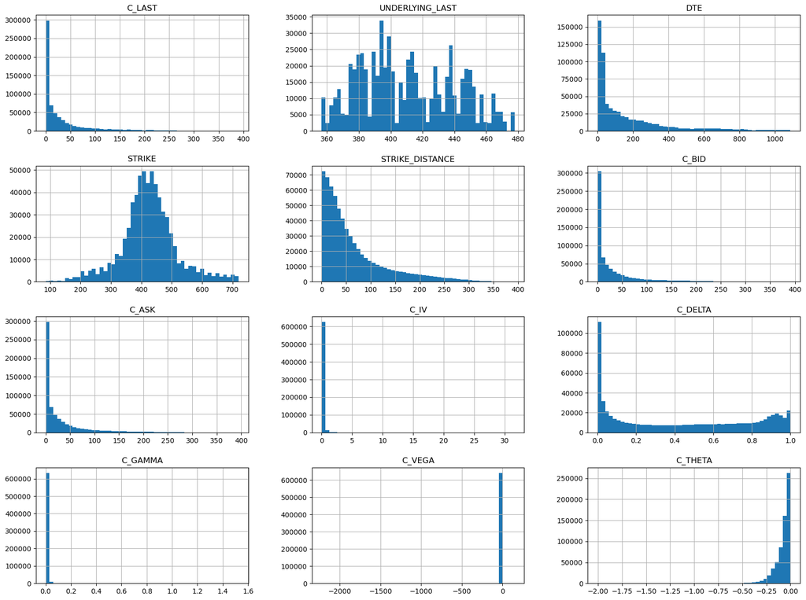

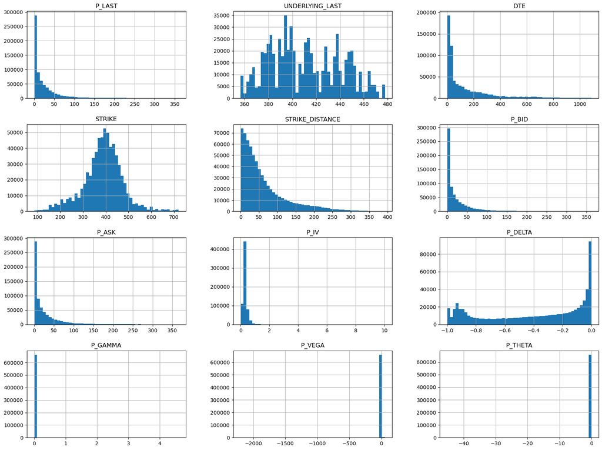

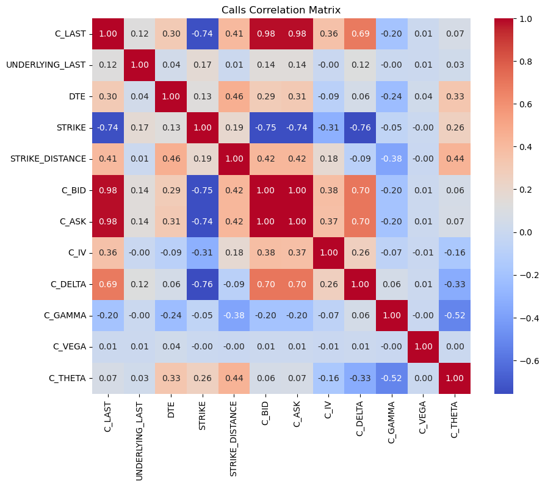

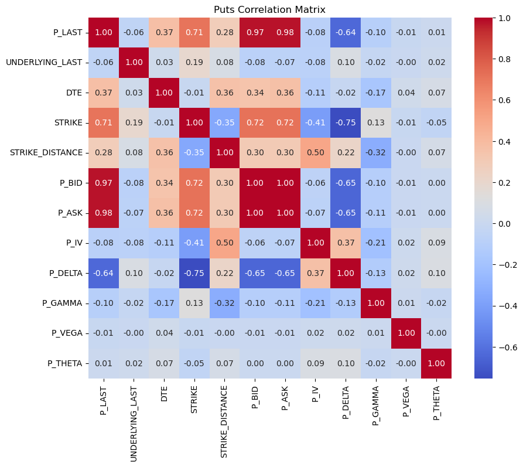

```python
# Histograms for the training calls and puts
train_calls.hist(bins=50, figsize=(20,15))
plt.show()

train_puts.hist(bins=50, figsize=(20,15))
plt.show()

# Correlation matrices
calls_matrix = train_calls.corr()
plt.figure(figsize=(10, 8))
sns.heatmap(calls_matrix, annot=True, cmap='coolwarm', fmt=".2f")
plt.title("Calls Correlation Matrix")
plt.show()
puts_matrix = train_puts.corr()
plt.figure(figsize=(10, 8))
sns.heatmap(puts_matrix, annot=True, cmap='coolwarm', fmt=".2f")
plt.title("Puts Correlation Matrix")
plt.show()
```

```python
# Separate the features and the target variable for calls and puts
X_train_calls = train_calls.drop('C_LAST', axis=1)
X_test_calls = test_calls.drop('C_LAST', axis=1)
y_train_calls = train_calls['C_LAST']
y_test_calls = test_calls['C_LAST']

X_train_puts = train_puts.drop('P_LAST', axis=1)
X_test_puts = test_puts.drop('P_LAST', axis=1)
y_train_puts = train_puts['P_LAST']
y_test_puts = test_puts['P_LAST']

# Normalize and standardize the input features
scaler = StandardScaler()
X_train_calls_scaled = scaler.fit_transform(X_train_calls)
X_test_calls_scaled = scaler.transform(X_test_calls)
X_train_puts_scaled = scaler.fit_transform(X_train_puts)
X_test_puts_scaled = scaler.transform(X_test_puts)

# X_train_calls_scaled = pd.DataFrame(X_train_calls_scaled).dropna()
# X_train_puts_scaled = pd.DataFrame(X_train_puts_scaled).dropna()
```

```python
# Run and fit the ML model with KNN
knn_calls = KNeighborsRegressor()
knn_puts = KNeighborsRegressor()
knn_calls.fit(X_train_calls_scaled, y_train_calls)
knn_puts.fit(X_train_puts_scaled, y_train_puts)

# Predict calues on the scaled testing dataset
y_pred_calls = knn_calls.predict(X_test_calls_scaled)
y_pred_puts = knn_puts.predict(X_test_puts_scaled)

# Calculate the predictive abilities of the model
mse_calls = mean_squared_error(y_test_calls, y_pred_calls)
mae_calls = mean_absolute_error(y_test_calls, y_pred_calls)
r2_calls = r2_score(y_test_calls, y_pred_calls)

mse_puts = mean_squared_error(y_test_puts, y_pred_puts)
mae_puts = mean_absolute_error(y_test_puts, y_pred_puts)
r2_puts = r2_score(y_test_puts, y_pred_puts)

# Print out statistics
print('Calls:')
print(f'Mean Square Error = {mse_calls}')
print(f'Mean Absolute Error = {mae_calls}')
print(f'Residual Squared = {r2_calls}')

print('\nPuts:')
print(f'Mean Square Error = {mse_puts}')
print(f'Mean Absolute Error = {mae_puts}')
print(f'Residual Squared = {r2_puts}')
```

```
Calls:
Mean Square Error = 55.12739195470178
Mean Absolute Error = 3.1698103494381256
Residual Squared = 0.9809279182626642

Puts:
Mean Square Error = 43.68895332001447
Mean Absolute Error = 2.8311723488961276
Residual Squared = 0.9719776815136438
```

```python
# Calculate Black-Scholes prices for the test datasets and add it to the dataframe
test_calls['BS_PRICE'] = test_calls.apply(black_scholes, option='call', axis=1)
test_puts['BS_PRICE'] = test_puts.apply(black_scholes, option='put', axis=1)

# # Scale the prices as well
# test_calls['BS_PRICE'] = scaler.transform(test_calls['BS_PRICE'].values.reshape(-1, 1))
# test_puts['BS_PRICE'] = scaler.transform(test_puts['BS_PRICE'].values.reshape(-1, 1))

# Compute the mean squared error of the KNN and Black-Scholes predictions
# Get the mean squared error from the KNN model and compare it with the Black-Scholes model
mse_calls_bs = mean_squared_error(y_test_calls, test_calls['BS_PRICE'])
mse_puts_bs = mean_squared_error(y_test_puts, test_puts['BS_PRICE'])

print('Calls')
print(f'Mean Square Error: \nKNN = {mse_calls}, Black-Scholes = {mse_calls_bs}')

print('\nPuts')
print(f'Mean Square Error: \nKNN = {mse_puts}, Black-Scholes = {mse_puts_bs}')
```

```
Calls
Mean Square Error:
KNN = 55.12739195470178, Black-Scholes = 101.0022218030855

Puts
Mean Square Error:
KNN = 43.68895332001447, Black-Scholes = 95.8368940949794
```

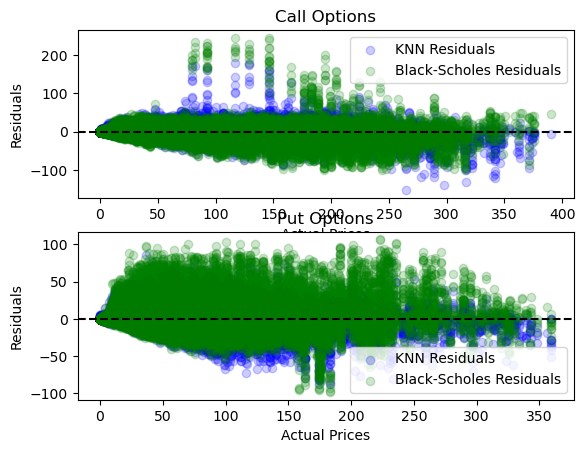

```python
# Calculate the residuals
res_knn_calls = y_pred_calls - y_test_calls
res_knn_puts = y_pred_puts - y_test_puts

res_bs_calls = test_calls['BS_PRICE'] - y_test_calls
res_bs_puts = test_puts['BS_PRICE'] - y_test_puts

# Plot call residuals
plt.subplot(2, 1, 1)
plt.title('Call Options')
plt.xlabel('Actual Prices')
plt.ylabel('Residuals')
plt.scatter(y_test_calls, res_knn_calls, color='blue', alpha=0.2, label='KNN Residuals')
plt.scatter(y_test_calls, res_bs_calls, color='green', alpha=0.2, label='Black-Scholes Residuals')
plt.axhline(y=0, color='black', linestyle='--')
plt.legend()

# Plot put residuals
plt.subplot(2, 1, 2)
plt.title('Put Options')
plt.xlabel('Actual Prices')
plt.ylabel('Residuals')
plt.scatter(y_test_puts, res_knn_puts, color='blue', alpha=0.2, label='KNN Residuals')
plt.scatter(y_test_puts, res_bs_puts, color='green', alpha=0.2, label='Black-Scholes Residuals')
plt.axhline(y=0, color='black', linestyle='--')
plt.legend()

plt.tight_layout()
plt.show()
```

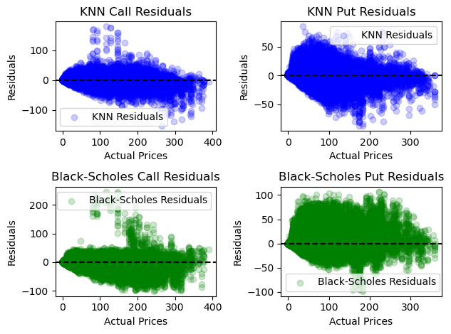

```python
# *** Individual residual graphs ***

# Plot KNN call residuals
plt.subplot(2, 2, 1)
plt.title('KNN Call Residuals')
plt.xlabel('Actual Prices')
plt.ylabel('Residuals')
plt.scatter(y_test_calls, res_knn_calls, color='blue', alpha=0.2, label='KNN Residuals')
plt.axhline(y=0, color='black', linestyle='--')
plt.legend()

# Plot KNN put residuals
plt.subplot(2, 2, 2)
plt.title('KNN Put Residuals')
plt.xlabel('Actual Prices')
plt.ylabel('Residuals')
plt.scatter(y_test_puts, res_knn_puts, color='blue', alpha=0.2, label='KNN Residuals')
plt.axhline(y=0, color='black', linestyle='--')
plt.legend()

# Plot BS call residuals
plt.subplot(2, 2, 3)
plt.title('Black-Scholes Call Residuals')
plt.xlabel('Actual Prices')
plt.ylabel('Residuals')
plt.scatter(y_test_calls, res_bs_calls, color='green', alpha=0.2, label='Black-Scholes Residuals')
plt.axhline(y=0, color='black', linestyle='--')
plt.legend()

# Plot BS put residuals
plt.subplot(2, 2, 4)
plt.title('Black-Scholes Put Residuals')
plt.xlabel('Actual Prices')
plt.ylabel('Residuals')
plt.scatter(y_test_puts, res_bs_puts, color='green', alpha=0.2, label='Black-Scholes Residuals')
plt.axhline(y=0, color='black', linestyle='--')
plt.legend()

plt.tight_layout()
plt.show()
```

```python
test_calls['res'] = test_calls['BS_PRICE'] - y_test_calls
test = test_calls.sort_values('res')
test
```

|  | C_LAST | UNDERLYING_LAST | DTE | STRIKE | STRIKE_DISTANCE | C_BID | C_ASK | C_IV | C_DELTA | C_GAMMA | C_VEGA | C_THETA | BS_PRICE | res |
| --- | --- | --- | --- | --- | --- | --- | --- | --- | --- | --- | --- | --- | --- | --- |
| 497301 | 243.70 | 373.83 | 94.00 | 235.0 | 138.8 | 137.93 | 140.82 | 0.62472 | 0.90649 | 0.00025 | 0.22704 | -0.07041 | 142.336296 | -101.363704 |
| 513985 | 193.70 | 375.08 | 87.00 | 285.0 | 90.1 | 92.91 | 93.75 | 0.41887 | 0.92543 | 0.00184 | 0.25528 | -0.06625 | 93.452236 | -100.247764 |
| 514755 | 315.99 | 375.08 | 178.04 | 160.0 | 215.1 | 215.30 | 216.92 | 0.54897 | 0.99071 | 0.00012 | 0.05591 | -0.01147 | 216.266943 | -99.723057 |
| 498640 | 247.60 | 373.83 | 367.00 | 230.0 | 143.8 | 148.72 | 152.96 | 0.35195 | 0.94521 | 0.00082 | 0.41821 | -0.02844 | 149.825707 | -97.774293 |
| 506435 | 158.38 | 366.89 | 218.04 | 319.0 | 47.9 | 61.33 | 62.67 | 0.28580 | 0.78354 | 0.00362 | 0.83428 | -0.06369 | 61.259676 | -97.120324 |
| ... | ... | ... | ... | ... | ... | ... | ... | ... | ... | ... | ... | ... | ... | ... |
| 6457 | 92.40 | 477.56 | 72.96 | 170.0 | 307.6 | 306.84 | 308.53 | 2.02695 | 0.85697 | 0.00001 | 0.21791 | -0.12515 | 323.112618 | 230.712618 |
| 2007 | 82.50 | 477.77 | 73.96 | 175.0 | 302.8 | 302.10 | 303.76 | 1.92523 | 0.85863 | -0.00002 | 0.22349 | -0.16017 | 317.403120 | 234.903120 |
| 43674 | 146.20 | 464.66 | 336.00 | 110.0 | 354.7 | 352.99 | 356.75 | 1.69088 | 0.84579 | 0.00000 | 0.32537 | -0.08106 | 386.082720 | 239.882720 |
| 2000 | 116.37 | 477.77 | 73.96 | 140.0 | 337.8 | 337.05 | 339.46 | 2.69809 | 0.84849 | 0.00000 | 0.19314 | -0.34787 | 360.777180 | 244.407180 |
| 30335 | 146.20 | 469.63 | 339.00 | 110.0 | 359.6 | 357.91 | 361.66 | 1.70904 | 0.84600 | 0.00005 | 0.32660 | -0.08154 | 391.911809 | 245.711809 |

160801 rows × 14 columns

## Problems and Challenges I Came Across

The first problem I encountered was cleaning the data and processing such a large 10+ GB csv file into a Pandas dataframe. I solved this using Pythons functions to preprocess the CSV file itself and clean the headers and records. Then I processed by chunking the data so that it can be processed incrementally instead of all at once.

There were many invalid or uncleaned records that had impossible values such as negative implied volatility. There were also problems with too little significant figures and numbers being cut off as 0. For example, many last option prices were 0 when that should be incredibly unlikely.

I had quite a bit of difficulty in visualizing the data as I didn't know how to represent the inputs and outputs in a meaningful way. Other than the typical describe and head functions as well as scatterplots and histograms, I had little experience with making understandable plots. Fortunately, I have found inspiration from other data science and machine learning projects to help me throughout the process.

The problem that took me the longest to figure out was forgetting to scale the output of the Black-Scholes prices after having already scaled the inputs of that are placed into the equaiton. This led it to have incredibly high Mean Squared Errors. The reason it took me so long to determine was that I was not sure whether the problems were from incorrect implementation of the functions or from having misrepresentative data.

## Conclusion

After a great deal of trial and error, I was able to get a model that was comparable with the Black-Scholes equation. However, the model has access to much more information with the Greek's that the Black-Scholes did not account for. I learned a great deal about the data science process such as data wrangling and data preprocessing as well machine learning techniques. I also came across several unexpected difficulties that I had to play around with the data in order to properly clean. I also learned about many of the limitations with the machine learning models and black-scholes equation. I believe that the next best steps forward are improving the data visualization, providing more accurate and verified data, and finally using and experimenting with different models.

# Future Areas of Improvement

- Experiment with different models and use more complex algorithms
- Find the best hyperparameters to improve the predictive ability of the model and reduce MSE
- Add much more data (Obtain options chain data from OptionsDX from several more years)
- Find other data sources to validate or replace current data source
- Improve data visualization

Thank you for taking the time to view my project!